# P2

### Plot 3

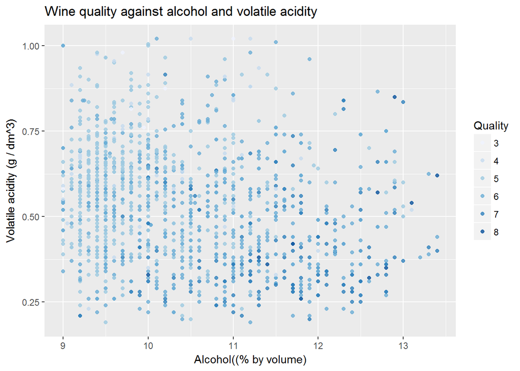

```r
ggplot(aes(x = alcohol, y = volatile.acidity, colour = qualityFactor),
       data = wine) +
  geom_point(alpha = 0.8)+
  scale_color_brewer(type = 'seq',  name = "Quality")+
  scale_x_continuous(lim=c(quantile(wine$alcohol,
                                  0.01),
                         quantile(wine$alcohol,
                                  0.99)))+
  scale_y_continuous(lim=c(quantile(wine$volatile.acidity,
                                0.01),
                       quantile(wine$volatile.acidity,
                                0.99)))+
  labs(x= "Alcohol((% by volume)", y = "Volatile acidity (g / dm^3)", title = "Wine quality against alcohol and volatile acidity")
```

在所有特征中，酒精含量与红酒品质具有最强的正相关性，而挥发性酸与红酒品质具有最强的负相关性。然而通过多变量分析可以看到，这两个化学成分单独对红酒品质影响较大，然而将两个特征结合在一起看是，却发现高品质红酒并不完全集中在图表的右下部，也就是说，不是完全拉高酒精含量，拉低挥发性酸，就一定能得到好红酒。在双变量分析中较为明显的特征，在多变量分析中结合了看，却并没有较明显的关系。可能是因为，不同葡萄酒内部是有自己风味上的平衡的，双变量涉及到一个一一对应的内部平衡问题，这一点是双变量分析图表中没法体现出来的。

## 7. 思考

我觉得双变量分析时可以看到某几个特征对红酒的品质有明显的影响，但多变量分析在图表上时却很难看出。

我有两个猜想： 1. 不同的葡萄酒内部是有自己风味上的平衡的，双变量涉及到一个一一对应的内部平衡问题，这一点是双变量分析图表中没法体现出来的。 2. 在网上检索时发现有专家提出[“哈洛普说他曾经将一款白葡萄酒中的二氧化硫含量从百万分之140降低到百万分之115，他发现二氧化硫含量的降低，大大提升了葡萄酒的品质。”](http://www.wine-world.com/culture/zx/20130823105931679)。这个下调的剂量是非常小的，哪怕现有的分析单位中进行了log转换，也没有到这个数量级，而且这个下调是一个控制变量的比较，和现在的数据分析并不相同。我觉得如果对葡萄酒的影响是单变量影响更大的话，那么对某一评分的酒，甚至同一种酒，加强某种进行某种变量的控制，在这一范围内进行评分会更有效果，可能也会更有利于酿造或贮藏技术的提高。。

除此以外 ，红葡萄酒和白葡萄酒有许多相类似的特征，但取值分布却会有较大的差异，比如酸度，白葡萄酒可能会更偏酸一点等。未来可以将两个数据集结合在一起进行比较。

## 8. 参考:

1. [Introducing R](http://data.princeton.edu/R/gettingStarted.html)
2. [数据分析？从一开始你就错了！探索性数据分析套路解读](https://zhuanlan.zhihu.com/p/29364225)
3. [Red and White Wine Quality by Daria Alekseeva](https://rstudio-pubs-static.s3.amazonaws.com/57835_c4ace81da9dc45438ad0c286bcbb4224.html)
4. [Red Wine Composition](http://waterhouse.ucdavis.edu/whats-in-wine/red-wine-composition)
5. [酸酸好滋味——详解高酸/低酸葡萄酒](http://www.wine-world.com/culture/pj/20131204171957985)
6. [从低到高，葡萄酒的酒精含量你知道多少？](http://www.wine-world.com/culture/pj/20151125093514134)
7. [Chloride concentration in red wines: influence of terroir and grape type](http://www.scielo.br/scielo.php?script=sci_arttext&pid=S0101-20612015000100095)
8. [When a wine is salty, and why it shouldn’t be](http://wineoscope.com/2015/10/02/when-a-wine-is-salty-and-why-it-shouldnt-be/) https://stackoverflow.com/questions/29278153/plotting-with-ggplot2-error-discrete-value-supplied-to-continuous-scale
9. [Plotting with ggplot2: Error: Discrete value supplied to continuous scale](https://stackoverflow.com/questions/29278153/plotting-with-ggplot2-error-discrete-value-supplied-to-continuous-scale)
10. [Red wine quality Data Analysis](https://rpubs.com/jadianes/red-wine-quality-analysis)
11. [Red Wine Quality Analysis](https://rpubs.com/szon0111/P4)
12. [Predicting Red Wine Quality: Exploratory Data Analysis](https://rpubs.com/jeknov/redwine)
13. [Red and White Wine Analysis](https://rpubs.com/ian_xxiao/98369)